# Analysis

Author

Xiaotong Liu

R preparation

```r
if (!requireNamespace("pacman", quietly = TRUE)) {
  install.packages("pacman")
}
library("pacman")
p_load(tidyverse, here, GGally, ppcor, lme4, lmtest, patchwork)

## read-in data
#if the data cannot be read, try df_noise_conjdisj <- read.csv(here::here("data",
#                                         "part2_estimation_task",
#                                         "noise_conj_disj.csv"))
df_noise_conjdisj <- read.csv(here::here("data_and_analysis", "data",
                                         "part2_estimation_task",
                                         "noise_conj_disj.csv"))
#155 participants

df_ranking <- read.csv(here::here("data_and_analysis", "data",
                                  "part3_ranking_task",
                                  "result_ranking.csv")) |>
  filter(id %in% df_noise_conjdisj$id) #143 participants

df_OSPAN <- read.csv(here::here("data_and_analysis", "data",
                                "part4_WMC_Gf",
                                "df_part4_OSPAN.csv")) |>
  filter(id %in% df_ranking$id) #87 participants

df_SSPAN <- read.csv(here::here("data_and_analysis", "data",
                                "part4_WMC_Gf",
                                "df_part4_SSPAN.csv")) |>
  filter(id %in% df_ranking$id) #87 participants

#df_RSPAN <- read.csv(here::here("data_and_analysis", "data",
#                                 "part4_WMC_Gf",
#                                 "df_part4_RSPAN.csv")) |>
#  filter(id %in% df_ranking$id)  #87 participants
###we decided to not use the RSPAN scores

df_HMT <- read.csv(here::here("data_and_analysis", "data",
                              "part4_WMC_Gf",
                              "df_HMT.csv")) |>
  dplyr::select(id, HMT_score = no_correct) |>
  dplyr::filter(id %in% df_ranking$id)

#creating a sub-directory for saving the plots
plots_dir <- file.path(getwd(), "plots")
if (!dir.exists(plots_dir)) dir.create(plots_dir, recursive = TRUE)
```

Data exclusion ：

```r
#part 2: excluding 2 participants who always responded 100\% or 90\%.
exclusion_noise <-read.csv(here::here("data_and_analysis", "data",
                                      "part2_estimation_task",
                                      "exclusion_part2_IDs.csv"
))

df_noise_conjdisj <- df_noise_conjdisj |>
 filter(! id %in% exclusion_noise$id) #|> #153 participants
 #filter(d_average >= 0 & d_average <= 0.5)

#part 3: excluding 8 (who translated German to English when performing the experiment)
# + 8(who failed the comprehension check question) = 16 participants
exclusion_ranking <- read.csv(here::here("data_and_analysis",
                                         "data", "part3_ranking_task",
                                   "exclusion_part3_IDs.csv"))

df_ranking <- df_ranking |> filter(! id %in% exclusion_ranking$id) |>
  filter(id %in% df_noise_conjdisj$id) #125 participants

#part 4: excluding 2 participants, one was excluded for translating German to English when performing the experiment, another for starting the experiment mutiple times
exclusion_WMGf <- read.csv(here::here("data_and_analysis", "data",
                                      "part4_WMC_Gf",
                                      "exclusion_part4_IDs.csv"))

df_OSPAN <- df_OSPAN |> filter(! id %in% exclusion_WMGf$id)
df_SSPAN <- df_SSPAN |> filter(! id %in% exclusion_WMGf$id)

WMC_result <- df_OSPAN |>
  full_join(df_SSPAN, by = c("id", "splength")) #85 participants

#excluding 9 participants, who did not meet the processing-task accuracy criterion (at least 85%) in both the operation and symmetry span322
WMC_result <- WMC_result  |>
  group_by(id)  |>
  fill(OSPAN_processing, SSPAN_processing, .direction = "updown")  |>
  mutate(OSPAN_pass = ifelse(OSPAN_processing >= 0.85, 1, 0),
         SSPAN_pass = ifelse(SSPAN_processing >= 0.85, 1, 0)) |>
  filter(OSPAN_pass == 1 & SSPAN_pass == 1 )

WMC_result <- WMC_result |>
  filter(id %in% df_ranking$id) #69 participants

df_HMT <- df_HMT |>
  filter(id %in% WMC_result$id) #69 participants
```

Demographic information:

```r
data_demo <- read.csv(here::here("data_and_analysis",
                                         "data",
                                 "part3_ranking_task",
                                   "data_demo.csv"))

data_demo_RQ1 <- data_demo |>
  filter(id %in% df_ranking$id)

data_demo_RQ1 |> group_by(gender) |> count()
```

```
# A tibble: 3 × 2
# Groups:   gender [3]
  gender         n
  <chr>      <int>
1 female        35
2 male          88
3 non-binary     2
```

```r
data_demo_RQ1 |>
  summarise(
    mean_age = mean(age),
    sd_age = sd(age),
    min_age = min(age),
    max_age = max(age)
  )
```

```
  mean_age   sd_age min_age max_age
1   28.304 6.951704      19      63
```

```r
data_demo_RQ2 <- data_demo |>
  filter(id %in% df_HMT$id)

data_demo_RQ2 |> group_by(gender) |> count()
```

```
# A tibble: 2 × 2
# Groups:   gender [2]
  gender     n
  <chr>  <int>
1 female    16
2 male      53
```

```r
data_demo_RQ2 |>
 summarise(
    mean_age = mean(age),
    sd_age = sd(age),
    min_age = min(age),
    max_age = max(age)
  )
```

```
  mean_age   sd_age min_age max_age
1 27.89855 7.853708      19      63
```

**Robustness check of the results:**

To assess the robustness of the results, in addition to the analyses reported in the main text, we repeated the analyses under alternative exclusion criteria: We (1) repeated the analyses without excluding any participant in Part 2 (the estimation task) (by skipping the code `df_noise_conjdisj <- df_noise_conjdisj |> filter(! id %in% exclusion_noise$id)`), and (2) repeated the analyses further excluding those participants whose estimated noise parameters lie outside of the theoretical ranges ( by running the code `df_noise_conjdisj <- df_noise_conjdisj |> filter(! id %in% exclusion_noise$id) |> filter(d_average >= 0 & d_average <= 0.5` instead). Across these specifications, the results were similar to the results reported in the main text and our substantive conclusions remained unchanged.

## Research Question 1

Association between the estiamted noise, number of illogical rankings, and additionally the count of conjunction and disjunction fallacies

**Visualization**:

```r
# prepare the dataset for the plot
df_ranking_aggregated <- df_ranking |>
  group_by(id) |>
  mutate(sum_illogical = sum(logical_pass))  |>  #the number of trials where the responses were illogical
  dplyr::select(id, sum_illogical, get_logic) |>
  unique()

aggregated_noise_illogical <- df_ranking_aggregated |>
  left_join(df_noise_conjdisj, by = "id") |>
  drop_na() |>
  ungroup() |>
  dplyr::select(id,
         d_average,
         #number_conj,
         #number_disj,
         sum_illogical,
         number_conj_disj,
         get_logic,
         x1_average,
         x2_average,
         z1_d,
         z2_d,
         z3_d,
         z4_d,
         z5_d,
         z6_d) #125 participants

#descriptive statistics
( summary_table <- aggregated_noise_illogical |>
  summarise(across(c(d_average, sum_illogical, number_conj_disj, get_logic),
            list(
              mean = ~mean(.x, na.rm = TRUE),
              sd   = ~sd(.x, na.rm = TRUE),
              min  = ~min(.x, na.rm = TRUE),
              max  = ~max(.x, na.rm = TRUE)
            ),
            .names = "{.col}_{.fn}")) |>
  mutate(across(everything(), ~round(.x, 2))))
```

```
# A tibble: 1 × 16
  d_average_mean d_average_sd d_average_min d_average_max sum_illogical_mean
           <dbl>        <dbl>         <dbl>         <dbl>              <dbl>
1           0.18         0.17         -0.06          0.87               9.06
# ℹ 11 more variables: sum_illogical_sd <dbl>, sum_illogical_min <dbl>,
#   sum_illogical_max <dbl>, number_conj_disj_mean <dbl>,
#   number_conj_disj_sd <dbl>, number_conj_disj_min <dbl>,
#   number_conj_disj_max <dbl>, get_logic_mean <dbl>, get_logic_sd <dbl>,
#   get_logic_min <dbl>, get_logic_max <dbl>
```

```r
#illogical rankings grouped by event-set condition
df_ranking_by_condition <- df_ranking |>
  group_by(id, condition) |>
  summarise(number_logical = sum(logical_pass), .groups = "drop")

df_ranking_by_condition |>
  group_by(condition) |>
  summarise(mean_no_logical = mean(number_logical),
            sd_no_logical   = sd(number_logical))
```

```
# A tibble: 2 × 3
  condition mean_no_logical sd_no_logical
  <chr>               <dbl>         <dbl>
1 edge                 2.87          2.05
2 middle               6.19          2.97
```

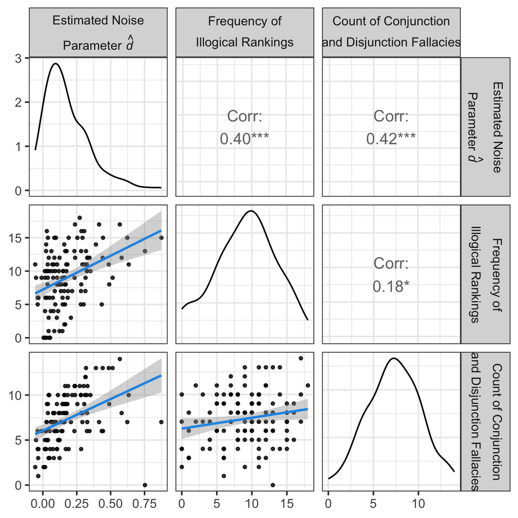

Pairwise plots for the estimated noise parameter, the number of illogical rankings, and the count of conjunction and disjunction fallacies (data from Parts 2 and 3)

```r
#plot
custom_labels <- c(
  "atop('Estimated Noise', 'Parameter ' * hat(italic(d)))",
  "atop('Frequency of', 'Illogical Rankings')",
  "atop('Count of Conjunction', 'and Disjunction Fallacies')"
)


lower_lm <- function(data, mapping,
                     se = TRUE, level = 0.95, linewidth = 1,
                     fullrange = TRUE) {
  ggplot(data = data, mapping = mapping) +
    geom_point(alpha = 0.8, size = 1) +
    geom_smooth(method = "lm",
                se = se, level = level,
                linewidth = linewidth, fullrange = fullrange,
                color = "#2297E6" )
}

( p1 <- ggpairs(
  aggregated_noise_illogical,
  columns = 2:4,
  columnLabels = custom_labels,
  labeller = "label_parsed",
   upper = list(continuous = wrap("cor", size = 5, digits = 2)),
  lower = list(continuous = wrap(lower_lm,
                                 se = TRUE, level = 0.95, linewidth = 1)),
  diag  = list(continuous = "densityDiag")
) +
  theme_bw(base_size = 14) )
```

```r
#save the plot
#ggsave(
#  filename = file.path(plots_dir, "noise_ranking_conjdisj.pdf"),
#  plot = p1,
#  width = 6.4, height = 6.4,
#  dpi = 300
#)
```

Statistical modelling:

**Pearson correlation** between the estimate noise and the number of illogical rankings:

```r
cor.test(aggregated_noise_illogical$d_average,
         aggregated_noise_illogical$sum_illogical,
                method = "pearson",
                conf.level = 0.95)
```

```
    Pearson's product-moment correlation

data:  aggregated_noise_illogical$d_average and aggregated_noise_illogical$sum_illogical
t = 4.8919, df = 123, p-value = 3.059e-06
alternative hypothesis: true correlation is not equal to 0
95 percent confidence interval:
 0.2453556 0.5408515
sample estimates:
      cor
0.4035746
```

**Pearson correlation** between the estimated noise and the count of disjunction and conjunction fallacies:

```r
cor.test(aggregated_noise_illogical$d_average,
aggregated_noise_illogical$number_conj_disj,
                method = "pearson",
                conf.level = 0.95)
```

```
    Pearson's product-moment correlation

data:  aggregated_noise_illogical$d_average and aggregated_noise_illogical$number_conj_disj
t = 5.1951, df = 123, p-value = 8.23e-07
alternative hypothesis: true correlation is not equal to 0
95 percent confidence interval:
 0.2685949 0.5582192
sample estimates:
      cor
0.4241944
```

**Pearson correlation** between the number of illogical rankings and the count of disjunction and conjunction fallacies:

```r
cor.test(aggregated_noise_illogical$sum_illogical,
aggregated_noise_illogical$number_conj_disj,
                method = "pearson",
                conf.level = 0.95)
```

```
    Pearson's product-moment correlation

data:  aggregated_noise_illogical$sum_illogical and aggregated_noise_illogical$number_conj_disj
t = 2.0598, df = 123, p-value = 0.04153
alternative hypothesis: true correlation is not equal to 0
95 percent confidence interval:
 0.007227642 0.347081225
sample estimates:
      cor
0.1826034
```

**Partial correlation** between the estimated noise parameter and the number of illogical rankings, controlling for the count of conjunction and disjunction fallacies:

```r
pc <- pcor.test(aggregated_noise_illogical[,"d_average"], aggregated_noise_illogical[,"sum_illogical"], aggregated_noise_illogical[,"number_conj_disj"], method = "pearson")
pc
```

```
   estimate      p.value statistic   n gp  Method
1 0.3662794 2.867343e-05  4.347842 125  1 pearson
```

95% confidence interval:

```r
r  <- as.numeric(pc$estimate)
n  <- pc$n
k  <- pc$gp                    # number of control vars
se <- 1 / sqrt(n - k - 3)      # Fisher z SE
z  <- atanh(r)
zcrit <- qnorm(0.975)
ci <- tanh(c(z - zcrit*se, z + zcrit*se))
ci
```

```
[1] 0.2030778 0.5096803
```

**Partial correlation** between the number of illogical rankings and the count of conjunction and disjunction fallacies, controlling for the estimated noise parameter

```r
pc2 <- pcor.test(aggregated_noise_illogical[,"number_conj_disj"], aggregated_noise_illogical[,"sum_illogical"],
                 aggregated_noise_illogical[,"d_average"], method = "pearson")
pc2
```

```
    estimate   p.value statistic   n gp  Method
1 0.01377026 0.8793499 0.1521119 125  1 pearson
```

95% confidence interval:

```r
r2  <- as.numeric(pc2$estimate)
n2  <- pc2$n
k2  <- pc2$gp                    # number of control vars
se2 <- 1 / sqrt(n2 - k2 - 3)      # Fisher z SE
z2  <- atanh(r2)
zcrit2 <- qnorm(0.975)
ci2 <- tanh(c(z2 - zcrit2*se2, z2 + zcrit2*se2))
ci2
```

```
[1] -0.1629420  0.1896265
```

**GLMM (logit link function; family: binomial) predicting the probability of logical rankings** with predictors: event-set type, the estimated noise parameter (the interaction between the event-set type and the estimated noise parameter, the trial number, as well as the logic rule question)

```r
#prepare the dataset for GLMMs
noise_illogical_by_trials <- df_ranking  |>
  left_join(df_noise_conjdisj, by = "id")  |>
  dplyr::select(id, f00, condition, logical_pass,
                d_average, number_conj_disj, get_logic) #125 participants
```

**Exploratory analysis: Is *even-set condition* a moderator?**

predictors: noise, event-set type, and their interactions

the interaction not significant

```r
options(contrasts = c("contr.treatment", "contr.poly"))

glmm_condition_noise_interaction <- glmer(logical_pass ~ condition + d_average +
                                            condition*d_average +
                                           (1 + condition|id),
                     data = noise_illogical_by_trials,
                     family = binomial(link = "logit"))

summary(glmm_condition_noise_interaction)
```

```
Generalized linear mixed model fit by maximum likelihood (Laplace
  Approximation) [glmerMod]
 Family: binomial  ( logit )
Formula: logical_pass ~ condition + d_average + condition * d_average +
    (1 + condition | id)
   Data: noise_illogical_by_trials

      AIC       BIC    logLik -2*log(L)  df.resid
   3525.9    3568.0   -1756.0    3511.9      2993

Scaled residuals:
    Min      1Q  Median      3Q     Max
-2.0816 -0.6465 -0.4068  0.7710  2.8849

Random effects:
 Groups Name            Variance Std.Dev. Corr
 id     (Intercept)     0.4146   0.6439
        conditionmiddle 0.3537   0.5948   0.12
Number of obs: 3000, groups:  id, 125

Fixed effects:
                          Estimate Std. Error z value Pr(>|z|)
(Intercept)               -1.70267    0.13474 -12.637  < 2e-16 ***
conditionmiddle            1.36698    0.15576   8.776  < 2e-16 ***
d_average                  2.25867    0.49148   4.596 4.31e-06 ***
conditionmiddle:d_average -0.08802    0.58769  -0.150    0.881
---
Signif. codes:  0 '***' 0.001 '**' 0.01 '*' 0.05 '.' 0.1 ' ' 1

Correlation of Fixed Effects:
            (Intr) cndtnm d_avrg
conditnmddl -0.486
d_average   -0.743  0.339
cndtnmddl:_  0.329 -0.742 -0.395
```

```r
get_or_table <- function(model, ci_level = 0.95) {
  # Get coefficients and SEs
  summ <- summary(model)$coefficients
  coefs <- summ[, "Estimate"]
  ses <- summ[, "Std. Error"]

  # Calculate critical value based on user-defined CI level
  tail_area <- (1 - ci_level) / 2
  zval <- abs(qnorm(tail_area))

  # The Math
  lower <- exp(coefs - zval * ses)
  upper <- exp(coefs + zval * ses)
  or <- exp(coefs)

  # Combine and round
  res <- round(cbind(OR = or, Lower = lower, Upper = upper), 3)
  return(as.data.frame(res))
}

get_or_table(glmm_condition_noise_interaction)
```

```
                             OR Lower  Upper
(Intercept)               0.182 0.140  0.237
conditionmiddle           3.923 2.891  5.324
d_average                 9.570 3.652 25.077
conditionmiddle:d_average 0.916 0.289  2.897
```

**Exploratory analysis: trial number as predictor**

```r
options(contrasts = c("contr.treatment", "contr.poly"))

glmm_condition_noise_f00 <- glmer(logical_pass ~ condition + d_average +
                                             f00 +
                                           (1 + condition |id),
                     data = noise_illogical_by_trials,
                     family = binomial(link = "logit"))

summary(glmm_condition_noise_f00)
```

```
Generalized linear mixed model fit by maximum likelihood (Laplace
  Approximation) [glmerMod]
 Family: binomial  ( logit )
Formula: logical_pass ~ condition + d_average + f00 + (1 + condition |      id)
   Data: noise_illogical_by_trials

      AIC       BIC    logLik -2*log(L)  df.resid
   3515.1    3557.1   -1750.5    3501.1      2993

Scaled residuals:
    Min      1Q  Median      3Q     Max
-2.1487 -0.6481 -0.4156  0.7729  2.8997

Random effects:
 Groups Name            Variance Std.Dev. Corr
 id     (Intercept)     0.4161   0.6450
        conditionmiddle 0.3466   0.5888   0.13
Number of obs: 3000, groups:  id, 125

Fixed effects:
                 Estimate Std. Error z value Pr(>|z|)
(Intercept)     -1.454606   0.145558  -9.993  < 2e-16 ***
conditionmiddle  1.357625   0.104417  13.002  < 2e-16 ***
d_average        2.231220   0.452423   4.932 8.15e-07 ***
f00             -0.019105   0.005784  -3.303 0.000956 ***
---
Signif. codes:  0 '***' 0.001 '**' 0.01 '*' 0.05 '.' 0.1 ' ' 1

Correlation of Fixed Effects:
            (Intr) cndtnm d_avrg
conditnmddl -0.311
d_average   -0.613  0.072
f00         -0.486 -0.041 -0.007
```

```r
get_or_table(glmm_condition_noise_f00)
```

```
                   OR Lower  Upper
(Intercept)     0.233 0.176  0.311
conditionmiddle 3.887 3.168  4.770
d_average       9.311 3.836 22.600
f00             0.981 0.970  0.992
```

**Exploratory analysis:** if the estimated noise parameter $\hat{d}$ explained additional variance in the frequency of illogical rankings beyond the effect of the event-set conditions

predictors: event-set type

```r
options(contrasts = c("contr.treatment", "contr.poly"))

glmm_condition <- glmer(logical_pass ~ condition +
                                           (1 + condition|id),
                     data = noise_illogical_by_trials,
                     family = binomial(link = "logit"))
```

predictors: noise, event-set type

```r
options(contrasts = c("contr.treatment", "contr.poly"))

glmm_condition_noise <- glmer(logical_pass ~ condition + d_average +
                                           (1 + condition|id),
                     data = noise_illogical_by_trials,
                     family = binomial(link = "logit"))

summary(glmm_condition_noise)
```

```
Generalized linear mixed model fit by maximum likelihood (Laplace
  Approximation) [glmerMod]
 Family: binomial  ( logit )
Formula: logical_pass ~ condition + d_average + (1 + condition | id)
   Data: noise_illogical_by_trials

      AIC       BIC    logLik -2*log(L)  df.resid
   3523.9    3560.0   -1756.0    3511.9      2994

Scaled residuals:
    Min      1Q  Median      3Q     Max
-2.0875 -0.6452 -0.4082  0.7713  2.8797

Random effects:
 Groups Name            Variance Std.Dev. Corr
 id     (Intercept)     0.4125   0.6422
        conditionmiddle 0.3549   0.5957   0.13
Number of obs: 3000, groups:  id, 125

Fixed effects:
                Estimate Std. Error z value Pr(>|z|)
(Intercept)      -1.6960     0.1268 -13.374  < 2e-16 ***
conditionmiddle   1.3496     0.1045  12.912  < 2e-16 ***
d_average         2.2298     0.4509   4.945  7.6e-07 ***
---
Signif. codes:  0 '***' 0.001 '**' 0.01 '*' 0.05 '.' 0.1 ' ' 1

Correlation of Fixed Effects:
            (Intr) cndtnm
conditnmddl -0.379
d_average   -0.706  0.071
```

```r
get_or_table(glmm_condition_noise)
```

```
                   OR Lower  Upper
(Intercept)     0.183 0.143  0.235
conditionmiddle 3.856 3.142  4.733
d_average       9.298 3.842 22.499
```

likelihood ratio test:

```r
lrtest(glmm_condition, glmm_condition_noise)
```

```
Likelihood ratio test

Model 1: logical_pass ~ condition + (1 + condition | id)
Model 2: logical_pass ~ condition + d_average + (1 + condition | id)
  #Df  LogLik Df  Chisq Pr(>Chisq)
1   5 -1767.3
2   6 -1756.0  1 22.747  1.848e-06 ***
---
Signif. codes:  0 '***' 0.001 '**' 0.01 '*' 0.05 '.' 0.1 ' ' 1
```

**Exploratory analysis**: double conjunction fallacy

```r
double_conj <- df_noise_conjdisj |>
  filter(id %in% aggregated_noise_illogical$id) |>
  dplyr::select(id, d_average, number_conj, number_double_conj) |>
  mutate(max_possible = 8)  |>
  mutate(prop_double_out_CFs = number_double_conj/number_conj) |>
  mutate(prop_double_out_CFs = replace(prop_double_out_CFs, is.nan(prop_double_out_CFs), NA))

#Item-level rate double conjunction fallacy
rate = sum(double_conj$number_double_conj) / sum(double_conj$max_possible)
#7.4%

#proportion of double conjunction fallacy in conjunction fallacy
rate2 = sum(double_conj$number_double_conj) / sum(double_conj$number_conj)
rate2
```

```
[1] 0.1401515
```

```r
#14.02%

#Person-level prevalence #44.8%
#The proportion of participants who committed at least one. This is "prevalence" in the epidemiological sense — a property of people, not judgments.
double_conj_des <- double_conj |>
  summarise(
    n            = n(),
    mean_count_double = mean(number_double_conj),
    sd = sd(number_double_conj),
    #participants on average provided 0.59 (median = 0, sd = 0.78) pair of double conjunction fallacy for 8 event pairs
    median_count_double = median(number_double_conj),
    n_any_double        = sum(number_double_conj > 0),
    # no.participants who committed at least one
    prop_any_double     = mean(number_double_conj > 0)
    # proportion who committed at least one
    )

test1 <- binom.test(double_conj_des$n_any_double,
                    125,
                    p = 0.5, alternative = "greater")
print(test1)
```

```
    Exact binomial test

data:  double_conj_des$n_any_double and 125
number of successes = 56, number of trials = 125, p-value = 0.8948
alternative hypothesis: true probability of success is greater than 0.5
95 percent confidence interval:
 0.3723845 1.0000000
sample estimates:
probability of success
                 0.448
```

## Research Question 2

Can noise predict illogical rankings independently of working memory capacity (WMC) and fluid intelligence (Gf)?

**Visualization:**

```r
#prepare the dataset for the plot
WMC_HMT <- WMC_result |>
  group_by(id) |>
  mutate(OSPAN_total = sum(OSPAN_partial_credit, na.rm = TRUE),
         SSPAN_total = sum(SSPAN_partial_credit, na.rm = TRUE)) |>
  dplyr::select(id, OSPAN_total, SSPAN_total) |>
  unique() |>
  mutate(WMC_composite = OSPAN_total + SSPAN_total) |>
  left_join(df_HMT, by = "id")

noise_illogical_WMC_Gf_aggregated <- aggregated_noise_illogical  |>
  left_join(WMC_HMT , by = "id")  |>
  ungroup() |>
  dplyr::select(id, d_average, WMC_composite, HMT_score, sum_illogical,
                number_conj_disj, get_logic,
                x1_average, x2_average, z1_d, z2_d, z3_d, z4_d, z5_d, z6_d) |>
  drop_na() #69 participants

( summary_table2 <- noise_illogical_WMC_Gf_aggregated |>
  summarise(across(c(d_average, WMC_composite, HMT_score,
                     sum_illogical, number_conj_disj),
            list(
              mean = ~mean(.x, na.rm = TRUE),
              sd   = ~sd(.x, na.rm = TRUE),
              min  = ~min(.x, na.rm = TRUE),
              max  = ~max(.x, na.rm = TRUE)
            ),
            .names = "{.col}_{.fn}")) |>
  mutate(across(everything(), ~round(.x, 2))) )
```

```
# A tibble: 1 × 20
  d_average_mean d_average_sd d_average_min d_average_max WMC_composite_mean
           <dbl>        <dbl>         <dbl>         <dbl>              <dbl>
1           0.18         0.18         -0.06          0.87               48.3
# ℹ 15 more variables: WMC_composite_sd <dbl>, WMC_composite_min <dbl>,
#   WMC_composite_max <dbl>, HMT_score_mean <dbl>, HMT_score_sd <dbl>,
#   HMT_score_min <dbl>, HMT_score_max <dbl>, sum_illogical_mean <dbl>,
#   sum_illogical_sd <dbl>, sum_illogical_min <dbl>, sum_illogical_max <dbl>,
#   number_conj_disj_mean <dbl>, number_conj_disj_sd <dbl>,
#   number_conj_disj_min <dbl>, number_conj_disj_max <dbl>
```

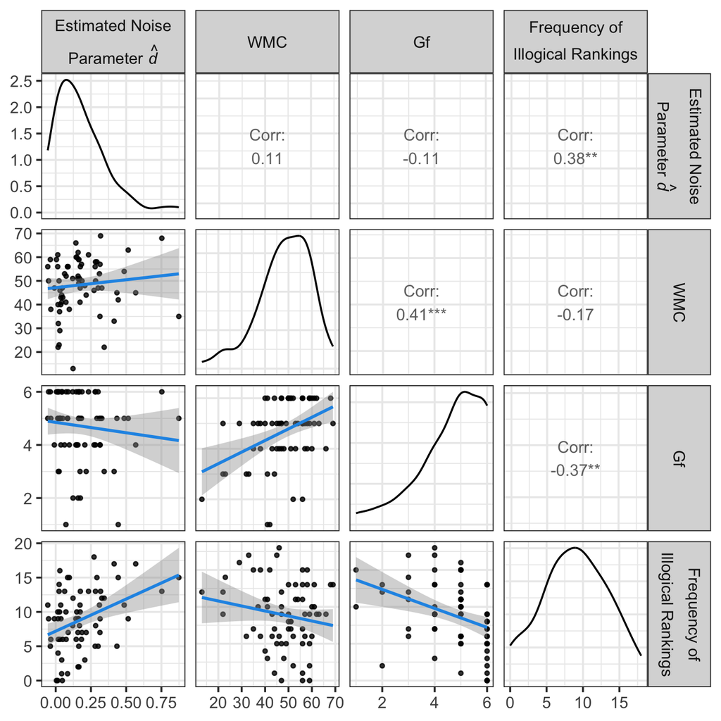

Pairwise plots for the estimated noise parameter, WMC score, Gf score and the number of illogical rankings (data from Parts 2, 3 and 4)

```r
#plot
custom_labels_noise_illogical_WMC <- c(
  "atop('Estimated Noise', 'Parameter ' * hat(italic(d)))",
   "WMC",
   "Gf",
  "atop('Frequency of', 'Illogical Rankings')"
  #"atop('Count of Conjunction', 'and Disjunction Errors')"
 )



( p2 <- ggpairs(
  noise_illogical_WMC_Gf_aggregated, columns = 2:5,
  columnLabels = custom_labels_noise_illogical_WMC,
  labeller = "label_parsed",
  upper = list(continuous = wrap("cor", size = 4, digits = 2)),
  lower = list(continuous = wrap(lower_lm, se = TRUE, level = 0.95, linewidth = 1)),
  diag  = list(continuous = "densityDiag")
) +
  theme_bw(base_size = 14) )
```

```r
#save the plot
#ggsave(
#  filename = file.path(plots_dir, "noise_illogical_HMT_WMC.pdf"),
#  plot = p2,
#  width = 7, height = 7,
#  dpi=300
#)
```

**Pearson correlation** between the number of illogical rankings and Gf score(HMT_score; the score for the HMT task)

```r
cor.test(noise_illogical_WMC_Gf_aggregated$HMT_score, noise_illogical_WMC_Gf_aggregated$sum_illogical,
                method = "pearson",
                conf.level = 0.95)
```

```
    Pearson's product-moment correlation

data:  noise_illogical_WMC_Gf_aggregated$HMT_score and noise_illogical_WMC_Gf_aggregated$sum_illogical
t = -3.2649, df = 67, p-value = 0.001727
alternative hypothesis: true correlation is not equal to 0
95 percent confidence interval:
 -0.5582172 -0.1466645
sample estimates:
       cor
-0.3704847
```

**Pearson correlation** between the number of illogical rankings and WMC score

```r
cor.test(noise_illogical_WMC_Gf_aggregated$WMC_composite, noise_illogical_WMC_Gf_aggregated$sum_illogical,
         method = "pearson",
         conf.level = 0.95)
```

```
    Pearson's product-moment correlation

data:  noise_illogical_WMC_Gf_aggregated$WMC_composite and noise_illogical_WMC_Gf_aggregated$sum_illogical
t = -1.4338, df = 67, p-value = 0.1563
alternative hypothesis: true correlation is not equal to 0
95 percent confidence interval:
 -0.39316708  0.06686914
sample estimates:
       cor
-0.1725423
```

**Pearson correlation** between the estimated noise parameter and WMC score

```r
cor.test(noise_illogical_WMC_Gf_aggregated$d_average, noise_illogical_WMC_Gf_aggregated$WMC_composite,
         method = "pearson",
         conf.level = 0.95)
```

```
    Pearson's product-moment correlation

data:  noise_illogical_WMC_Gf_aggregated$d_average and noise_illogical_WMC_Gf_aggregated$WMC_composite
t = 0.88032, df = 67, p-value = 0.3818
alternative hypothesis: true correlation is not equal to 0
95 percent confidence interval:
 -0.1331183  0.3351304
sample estimates:
      cor
0.1069314
```

**Pearson correlation** between the estimated noise parameter and Gf score

```r
cor.test(noise_illogical_WMC_Gf_aggregated$d_average, noise_illogical_WMC_Gf_aggregated$HMT_score,
         method = "pearson",
         conf.level = 0.95)
```

```
    Pearson's product-moment correlation

data:  noise_illogical_WMC_Gf_aggregated$d_average and noise_illogical_WMC_Gf_aggregated$HMT_score
t = -0.91664, df = 67, p-value = 0.3626
alternative hypothesis: true correlation is not equal to 0
95 percent confidence interval:
 -0.3390402  0.1287829
sample estimates:
       cor
-0.1112899
```

**GLMM (logit link function; family: binomial) predicting the probability of logical rankings** with predictors: event-set type, the estimated noise parameter, WMC score and Gf score.

```r
#prepare the dataset for GLMMs
noise_illogical_HMT_WMC_trials <- df_ranking |>
  dplyr::select(id, f00, condition, logical_pass, get_logic) |>
  left_join(WMC_HMT, by = "id") |>
  left_join(df_noise_conjdisj, by = "id") |>
  dplyr::select(id, f00, condition, logical_pass, get_logic, WMC_composite, HMT_score, d_average) |>
    drop_na() #69 participants
```

predictors: event-set type (condition), noise (d_average), WMC score (WMC_composite), Gf score (HMT_score)

```r
glmm_condtion_noise_WMC_Gf <- glmer(logical_pass ~ condition + d_average +
                         WMC_composite + HMT_score +
                       (1 + condition |id),
                     data = noise_illogical_HMT_WMC_trials,
                     family = binomial(link = "logit"),
                     control = glmerControl(optimizer="bobyqa",
                                   optCtrl=list(maxfun=1e5)))
summary(glmm_condtion_noise_WMC_Gf)
```

```
Generalized linear mixed model fit by maximum likelihood (Laplace
  Approximation) [glmerMod]
 Family: binomial  ( logit )
Formula: logical_pass ~ condition + d_average + WMC_composite + HMT_score +
    (1 + condition | id)
   Data: noise_illogical_HMT_WMC_trials
Control: glmerControl(optimizer = "bobyqa", optCtrl = list(maxfun = 1e+05))

      AIC       BIC    logLik -2*log(L)  df.resid
   1914.9    1958.2    -949.5    1898.9      1648

Scaled residuals:
    Min      1Q  Median      3Q     Max
-2.0414 -0.6423 -0.4068  0.7540  3.0866

Random effects:
 Groups Name            Variance Std.Dev. Corr
 id     (Intercept)     0.3410   0.5839
        conditionmiddle 0.4534   0.6734   0.18
Number of obs: 1656, groups:  id, 69

Fixed effects:
                 Estimate Std. Error z value Pr(>|z|)
(Intercept)     -0.281402   0.493929  -0.570 0.568867
conditionmiddle  1.344948   0.147040   9.147  < 2e-16 ***
d_average        2.017306   0.560180   3.601 0.000317 ***
WMC_composite   -0.008036   0.009851  -0.816 0.414647
HMT_score       -0.218332   0.088645  -2.463 0.013778 *
---
Signif. codes:  0 '***' 0.001 '**' 0.01 '*' 0.05 '.' 0.1 ' ' 1

Correlation of Fixed Effects:
            (Intr) cndtnm d_avrg WMC_cm
conditnmddl -0.057
d_average   -0.181  0.056
WMC_compost -0.568 -0.011 -0.164
HMT_score   -0.443 -0.062  0.140 -0.425
```

Predictors: event-set type (condition), noise (d_average), WMC score (WMC_composite), Gf score (HMT_score), interaction between condition and WMC score, interaction between condition and Gf score

```r
glmm_condtion_noise_WMC_Gf_interactions <- glmer(logical_pass ~ condition + d_average +
                         WMC_composite + HMT_score +
                         condition*d_average + condition*HMT_score + condition*WMC_composite +
                        (1 + condition |id),
                     data = noise_illogical_HMT_WMC_trials,
                     family = binomial(link = "logit"),
                     control = glmerControl(optimizer="bobyqa",
                                   optCtrl=list(maxfun=1e5)))

summary(glmm_condtion_noise_WMC_Gf_interactions)
```

```
Generalized linear mixed model fit by maximum likelihood (Laplace
  Approximation) [glmerMod]
 Family: binomial  ( logit )
Formula: logical_pass ~ condition + d_average + WMC_composite + HMT_score +
    condition * d_average + condition * HMT_score + condition *
    WMC_composite + (1 + condition | id)
   Data: noise_illogical_HMT_WMC_trials
Control: glmerControl(optimizer = "bobyqa", optCtrl = list(maxfun = 1e+05))

      AIC       BIC    logLik -2*log(L)  df.resid
   1920.4    1980.0    -949.2    1898.4      1645

Scaled residuals:
    Min      1Q  Median      3Q     Max
-2.0401 -0.6390 -0.4085  0.7581  3.0426

Random effects:
 Groups Name            Variance Std.Dev. Corr
 id     (Intercept)     0.3397   0.5828
        conditionmiddle 0.4477   0.6691   0.19
Number of obs: 1656, groups:  id, 69

Fixed effects:
                               Estimate Std. Error z value Pr(>|z|)
(Intercept)                   -0.373523   0.530272  -0.704 0.481185
conditionmiddle                1.668793   0.688882   2.422 0.015416 *
d_average                      2.104843   0.600966   3.502 0.000461 ***
WMC_composite                 -0.008528   0.010663  -0.800 0.423815
HMT_score                     -0.196675   0.096494  -2.038 0.041529 *
conditionmiddle:d_average     -0.338348   0.782478  -0.432 0.665446
conditionmiddle:HMT_score     -0.072273   0.123525  -0.585 0.558487
conditionmiddle:WMC_composite  0.001546   0.013734   0.113 0.910377
---
Signif. codes:  0 '***' 0.001 '**' 0.01 '*' 0.05 '.' 0.1 ' ' 1

Correlation of Fixed Effects:
            (Intr) cndtnm d_avrg WMC_cm HMT_sc cndt:_ c:HMT_
conditnmddl -0.366
d_average   -0.177  0.064
WMC_compost -0.565  0.207 -0.161
HMT_score   -0.443  0.164  0.122 -0.432
cndtnmddl:_  0.064 -0.168 -0.364  0.057 -0.029
cndtnm:HMT_  0.166 -0.450 -0.030  0.172 -0.400  0.130
cndtnm:WMC_  0.209 -0.570  0.057 -0.381  0.172 -0.167 -0.424
```

**Z-transform continuous predictors for the ease of interpretation:**

```r
#prepare the dataset:
WMC_mean <- mean(WMC_HMT$WMC_composite) #48.33333
WMC_sd <- sd(WMC_HMT$WMC_composite) #11.36774
hmt_mean <- mean(WMC_HMT$HMT_score) #4.710145
hmt_sd <- sd(WMC_HMT$HMT_score) #1.28454

WMC_HMT_z <- WMC_HMT |>
  mutate(WMC_z =  (WMC_composite - WMC_mean) / WMC_sd,
         HMT_z = (HMT_score - hmt_mean) / hmt_sd)

df_noise_conjdisj_z <- df_noise_conjdisj |>
  filter(id %in% WMC_HMT_z$id)

noise_mean <- mean(df_noise_conjdisj_z$d_average)
noise_sd <- sd(df_noise_conjdisj_z$d_average)

df_noise_conjdisj_z <- df_noise_conjdisj_z |>
  mutate(noise_z = (d_average - noise_mean)/noise_sd)

noise_illogical_HMT_WMC_trials_z <- df_ranking |>
  left_join(WMC_HMT_z , by = "id") |>
  left_join(df_noise_conjdisj_z, by = "id") |>
  dplyr::select(id, f00, condition, logical_pass, number_conj_disj,
         noise_z, WMC_z , HMT_z, get_logic) |>
  drop_na()

#GLMM:
glmm_z_condition_noise_WMC_Gf <- glmer(logical_pass ~ condition + noise_z +
                         WMC_z + HMT_z +
                       (1 + condition |id),
                     data = noise_illogical_HMT_WMC_trials_z,
                     family = binomial(link = "logit"),
                     control = glmerControl(optimizer="bobyqa",
                                   optCtrl=list(maxfun=1e5)))
summary(glmm_z_condition_noise_WMC_Gf)
```

```
Generalized linear mixed model fit by maximum likelihood (Laplace
  Approximation) [glmerMod]
 Family: binomial  ( logit )
Formula: logical_pass ~ condition + noise_z + WMC_z + HMT_z + (1 + condition |
    id)
   Data: noise_illogical_HMT_WMC_trials_z
Control: glmerControl(optimizer = "bobyqa", optCtrl = list(maxfun = 1e+05))

      AIC       BIC    logLik -2*log(L)  df.resid
   1914.9    1958.2    -949.5    1898.9      1648

Scaled residuals:
    Min      1Q  Median      3Q     Max
-2.0414 -0.6423 -0.4068  0.7540  3.0866

Random effects:
 Groups Name            Variance Std.Dev. Corr
 id     (Intercept)     0.3410   0.5839
        conditionmiddle 0.4534   0.6734   0.18
Number of obs: 1656, groups:  id, 69

Fixed effects:
                Estimate Std. Error z value Pr(>|z|)
(Intercept)     -1.33748    0.11798 -11.336  < 2e-16 ***
conditionmiddle  1.34495    0.14704   9.147  < 2e-16 ***
noise_z          0.36818    0.10224   3.601 0.000317 ***
WMC_z           -0.09134    0.11199  -0.816 0.414684
HMT_z           -0.28045    0.11387  -2.463 0.013780 *
---
Signif. codes:  0 '***' 0.001 '**' 0.01 '*' 0.05 '.' 0.1 ' ' 1

Correlation of Fixed Effects:
            (Intr) cndtnm nois_z WMC_z
conditnmddl -0.455
noise_z     -0.076  0.056
WMC_z        0.013 -0.011 -0.164
HMT_z        0.084 -0.062  0.140 -0.425
```

Predictor coefficients:

```r
round(coef(summary(glmm_z_condition_noise_WMC_Gf)),2)
```

```
                Estimate Std. Error z value Pr(>|z|)
(Intercept)        -1.34       0.12  -11.34     0.00
conditionmiddle     1.34       0.15    9.15     0.00
noise_z             0.37       0.10    3.60     0.00
WMC_z              -0.09       0.11   -0.82     0.41
HMT_z              -0.28       0.11   -2.46     0.01
```

Odds ratios (OR) of predictors:

```r
get_or_table(glmm_z_condition_noise_WMC_Gf)
```

```
                   OR Lower Upper
(Intercept)     0.263 0.208 0.331
conditionmiddle 3.838 2.877 5.120
noise_z         1.445 1.183 1.766
WMC_z           0.913 0.733 1.137
HMT_z           0.755 0.604 0.944
```

**Exploratory analysis**: Did Gf scores differ significantly between participants who correctly identified the logic of the mathematical notations and those who did not?

```r
noise_illogical_WMC_Gf_aggregated |>
  filter(get_logic == "FALSE") |>
  summarise(mean_Gf = mean(HMT_score),
            sd_Gf = sd(HMT_score))
```

```
# A tibble: 1 × 2
  mean_Gf sd_Gf
    <dbl> <dbl>
1     4.5  1.26
```

```r
noise_illogical_WMC_Gf_aggregated |>
  filter(get_logic == "TRUE") |>
  summarise(mean_Gf = mean(HMT_score),
            sd_Gf = sd(HMT_score))
```

```
# A tibble: 1 × 2
  mean_Gf sd_Gf
    <dbl> <dbl>
1    5.47  1.13
```

```r
t.test(HMT_score ~ get_logic, data = noise_illogical_WMC_Gf_aggregated)
```

```
    Welch Two Sample t-test

data:  HMT_score by get_logic
t = -2.8678, df = 24.57, p-value = 0.00836
alternative hypothesis: true difference in means between group FALSE and group TRUE is not equal to 0
95 percent confidence interval:
 -1.6615025 -0.2718308
sample estimates:
mean in group FALSE  mean in group TRUE
           4.500000            5.466667
```

**Exploratory analysis**: Correlate each probabilistic expression with WMC and Gf scores

Correlating each probabilistic expression with WMC：

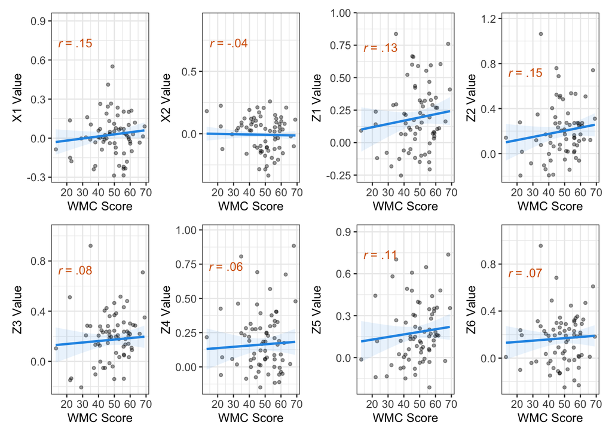

```r
noise_illogical_WMC_Gf_aggregated <- noise_illogical_WMC_Gf_aggregated |>
  rename(X1 =  x1_average,
         X2 = x2_average,
         Z1 = z1_d,
         Z2 = z2_d,
         Z3 = z3_d,
         Z4 = z4_d,
         Z5 = z5_d,
         Z6 = z6_d )

r_label <- function(x, y, italic = TRUE) {
  test  <- cor.test(x, y)
  r     <- unname(test$estimate)
  p     <- test$p.value
  stars <- if (p < .001) "***" else
    if (p < .01) "**" else
      if (p < .05) "*" else
        if (p < .10) "." else ""

  r_txt <- sub("^(-?)0\\.", "\\1.", sprintf("%.2f", r))

  if (italic) paste0("italic(r)~'= ", r_txt, stars, "'")
  else        paste0("r = ", r_txt, stars)
}

wmc_z <- function(var, data, xvar = "WMC_composite",
                  xlab = "WMC Score") {

  lab <- r_label(data[[xvar]], data[[var]])

  ggplot(data, aes(x = .data[[xvar]], y = .data[[var]])) +
    geom_jitter(alpha = 0.4, size = 1, width = 0.2, height = 0.2) +
    geom_smooth(method = "lm", se = TRUE,
                color = "#2297E6", fill = "#2297E6", alpha = 0.1) +
    annotate("text",
             x = -Inf, y = 0.8, hjust = -0.2, vjust = 1.5,
             label = r_label(data[[xvar]], data[[var]]),
             parse = TRUE,
             size = 3.5, color = "#D55E00", fontface = "bold") +
    scale_y_continuous(expand = expansion(mult = c(0.05, 0.15))) +
    labs(x = xlab,
         y = paste(var, "Value"))+
    theme_bw(base_size = 10) +
    theme(plot.title = element_text(hjust = 0.5, size = 11, face = "bold"),
          axis.text = element_text(size = 9))
}

plots_wmc <- lapply(c("X1", "X2",
                      "Z1", "Z2", "Z3",
                  "Z4", "Z5", "Z6"), wmc_z,
                data = noise_illogical_WMC_Gf_aggregated)

names(plots_wmc) <- c("X1", "X2",
                      "Z1", "Z2", "Z3",
                      "Z4", "Z5", "Z6")

p_wmc <- wrap_plots(plots_wmc[c("X1", "X2",
                                "Z1", "Z2", "Z3",
                                "Z4", "Z5", "Z6")],  ncol =4)

p_wmc
```

Correlating each probabilistic expression with Gf Score：

```r
Gf_z <- function(var, data, xvar = "HMT_score",
                  xlab = "Gf Score") {

  lab <- r_label(data[[xvar]], data[[var]])

  ggplot(data, aes(x = .data[[xvar]], y = .data[[var]])) +
    geom_jitter(alpha = 0.4, size = 1, width = 0.2, height = 0.2) +
    geom_smooth(method = "lm", se = TRUE,
                color = "#2297E6", fill = "#2297E6", alpha = 0.1) +
    annotate("text",
             x = -Inf, y = 0.85, hjust = -0.2, vjust = 1.5,
             label = r_label(data[[xvar]], data[[var]]),
             parse = TRUE,
             size = 3.5, color = "#D55E00", fontface = "bold") +
    scale_y_continuous(expand = expansion(mult = c(0.05, 0.15))) +
    labs(x = xlab,
         y = paste(var, "Value"))+
    theme_bw(base_size = 10) +
    theme(plot.title = element_text(hjust = 0.5, size = 11, face = "bold"),
          axis.text = element_text(size = 9))
}

plots_Gf <- lapply(c("X1", "X2",
                     "Z1", "Z2", "Z3",
                     "Z4", "Z5", "Z6"), Gf_z,
                    data = noise_illogical_WMC_Gf_aggregated)

names(plots_Gf) <-c("X1", "X2", "Z1", "Z2", "Z3", "Z4", "Z5", "Z6")

p_gf  <- wrap_plots(plots_Gf[c("X1", "X2",
                               "Z1", "Z2", "Z3",
                               "Z4", "Z5", "Z6")],  ncol = 4)

p_gf_wmc <- (wrap_elements(p_wmc) / wrap_elements(p_gf)) +
  plot_annotation(tag_levels = "A") &
  theme(plot.tag = element_text(face = "bold", size = 12))

ggsave(
  filename = file.path(plots_dir, "z1_z6_wmc_gf.pdf"),
  plot = p_gf_wmc,
  width = 7, height = 7,
)
```

**Exploratory analysis**: Correlating double conjunction fallacy with WMC and Gf scores

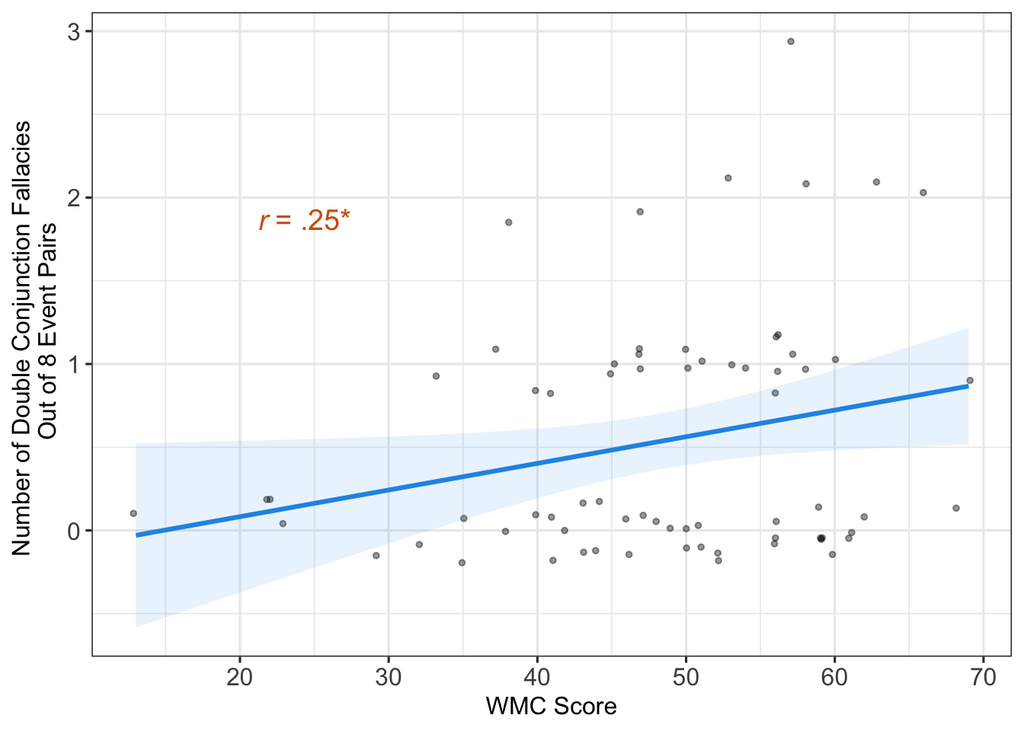

```r
double_conj_WMC_HMT <- double_conj  |>
  left_join(WMC_HMT , by = "id")  |>
  filter(id %in% noise_illogical_WMC_Gf_aggregated$id)

#correlate no.of double CFs with WMC
double_conj_WMC_HMT2 <- double_conj_WMC_HMT |>
  filter(number_double_conj != 3 &
           WMC_composite >= 30)

ggplot(double_conj_WMC_HMT, aes(x = WMC_composite, y = number_double_conj)) +
  geom_jitter(alpha = 0.4, size = 1, width = 0.2, height = 0.2) +
  geom_smooth(method = "lm", se = TRUE,
              color = "#2297E6", fill = "#2297E6", alpha = 0.1) +
  annotate("text",
           x = 20, y = 2, hjust = -0.2, vjust = 1.5,
           label = r_label(double_conj_WMC_HMT[["WMC_composite"]],
                           double_conj_WMC_HMT[["number_double_conj"]]),
           parse = TRUE,
           size = 5, color = "#D55E00", fontface = "bold") +
  labs(x = "WMC Score",
       y = "Number of Double Conjunction Fallacies \n Out of 8 Event Pairs") +
  theme_bw(base_size = 12) +
  theme(axis.text = element_text(size = 12))
```

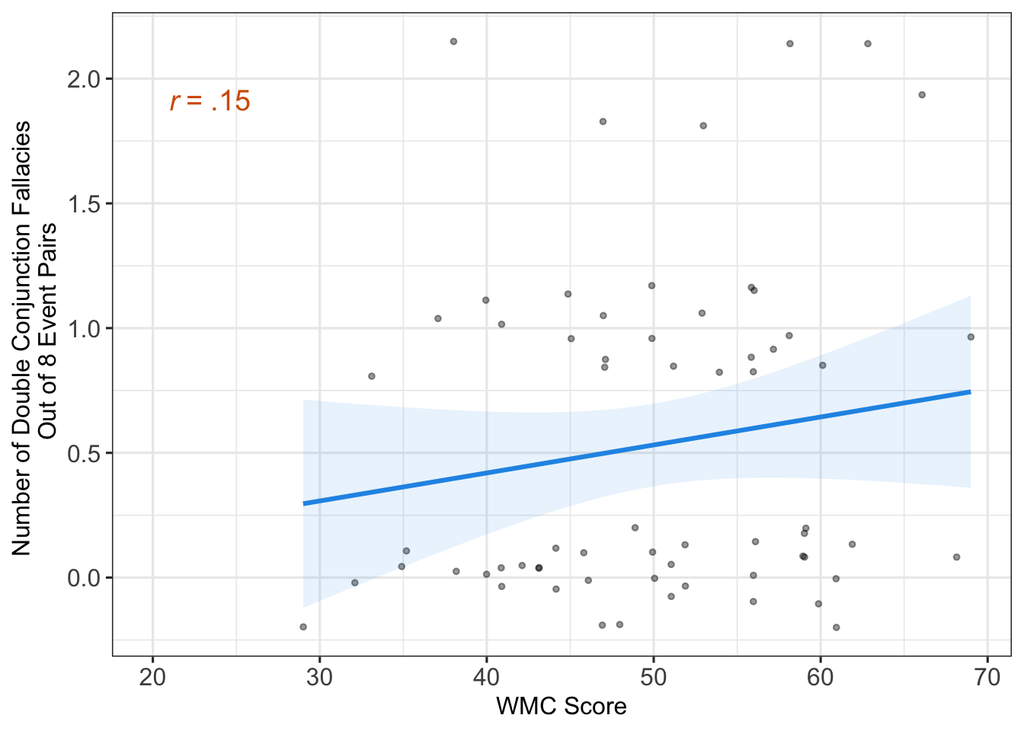

```r
double_conj_WMC_HMT2 <- double_conj_WMC_HMT |>
  filter(number_double_conj != 3 & WMC_composite >= 25 )

ggplot(double_conj_WMC_HMT2, aes(x = WMC_composite, y = number_double_conj)) +
  geom_jitter(alpha = 0.4, size = 1, width = 0.2, height = 0.2) +
  geom_smooth(method = "lm", se = TRUE,
              color = "#2297E6", fill = "#2297E6", alpha = 0.1) +
  annotate("text",
           x = 20, y = 2, hjust = -0.2, vjust = 1.5,
           label = r_label(double_conj_WMC_HMT2[["WMC_composite"]],
                           double_conj_WMC_HMT2[["number_double_conj"]]),
           parse = TRUE,
           size = 5, color = "#D55E00", fontface = "bold") +
  labs(x = "WMC Score",
       y = "Number of Double Conjunction Fallacies \n Out of 8 Event Pairs") +
  theme_bw(base_size = 12) +
  theme(axis.text = element_text(size = 12))
```

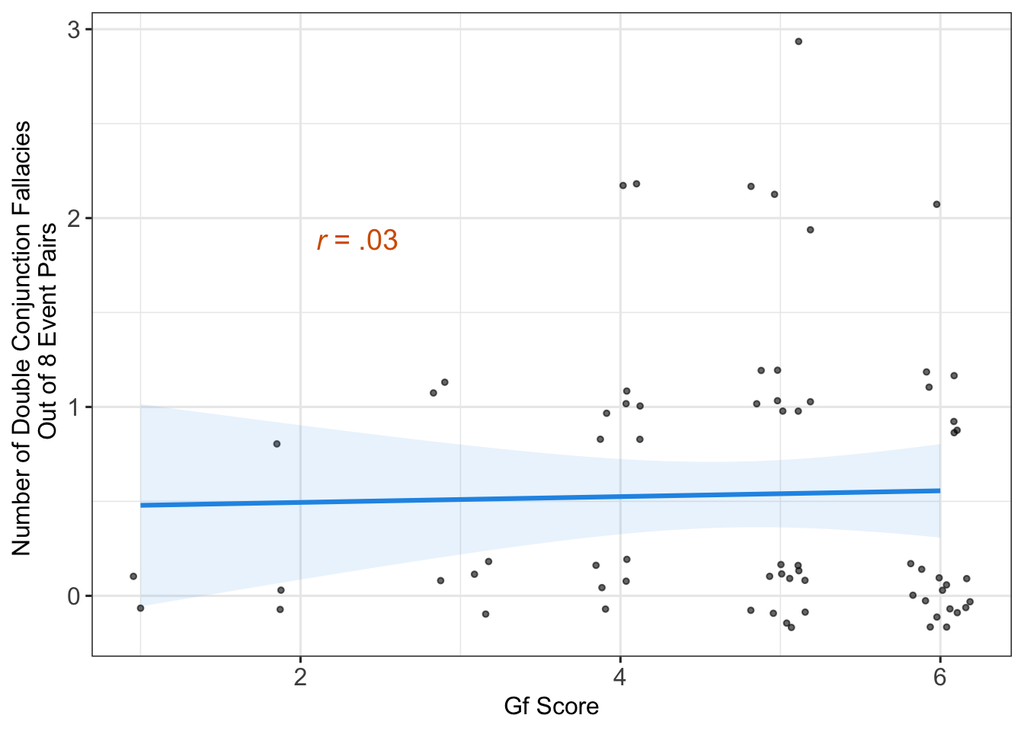

```r
#correlate no.of double CFs with Gf
ggplot(double_conj_WMC_HMT, aes(x = HMT_score, y = number_double_conj)) +
  geom_jitter(alpha = 0.6, size = 1, width = 0.2, height = 0.2) +
  geom_smooth(method = "lm", se = TRUE,
              color = "#2297E6", fill = "#2297E6", alpha = 0.1) +
  annotate("text",
           x = 2, y = 2, hjust = -0.2, vjust = 1.5,
           label = r_label(double_conj_WMC_HMT[["HMT_score"]],
                           double_conj_WMC_HMT[["number_double_conj"]]),
           parse = TRUE,
           size = 5, color = "#D55E00", fontface = "bold") +
  labs(x = "Gf Score",
       y = "Number of Double Conjunction Fallacies \n Out of 8 Event Pairs") +
  theme_bw(base_size = 12) +
  theme(axis.text = element_text(size = 12))
```